# Automobile complaint Analysis

Sayan Banerjee

August 2, 2017

# 1 Synopsis

This is analysis of complaints for an automobile company. This includes topic analysis and sentiment analysis.

Loading the required packages for the data analysis

```r
library(ggplot2)

library(syuzhet)
library(NLP)
library(tm)
library(slam)
library(openNLP)
library(quanteda)
library(lexRankr)
library(LSAfun)

library(RWeka)
library(cluster)
library(dendextend)

library(wordcloud)

library(topicmodels)
library(Rmpfr)

library(dplyr)
library(lazyeval)
library(stringi)
library(stringr)
library(corrplot)

library(shiny)
library(LDAvis)
library(servr)

library(igraph)
library(visNetwork)
library(RColorBrewer)

library(knitr)
library(xtable)
```

# 2 User defined function

All user defined functions are currently hidden

# 3 Read input data

```r
compDF <- read.csv("D:/Data Science/Automobile complaint analysis/input/auto_complaint.csv",
                      stringsAsFactors = F)

print(xtable(strtable(compDF)),
      type="html",include.rownames = FALSE)
```

| variable | class | levels | examples |
| --- | --- | --- | --- |
| S.No. | integer |  | 1, 2, 3, 4, … |
| Complaint.Heading | character |  | NA, … |
| Username | character |  | “”, “Abhilash Balakrishnan”, “Ashok Matadeen Kumar”, … |
| Complaint.Text | character |  | NA, … |

# 4 Data pre-processing

## 4.1 POS tagging

Visualizing POS data for few complaints

```r
sample_pos <- tagPOS(compDF[1,"Complaint.Text"])

sample_pos$POStagged
```

[1] “My/PRP$ vehicle/NN no/RB :/: AS/IN 01/CD BV/NNP 5458/CD Hyundai/NNP Eon/NNP bought/VBD in/IN the/DT month/NN of/IN November/NNP 2015/CD ./. Since/IN the/DT purchase/NN I/PRP am/VBP complaining/VBG about/IN the/DT mileage/NN issues/NNS which/WDT never/RB been/VBN resolved/VBN ./. Recently/RB I/PRP took/VBD the/DT vehicle/NN to/TO the/DT same/JJ service/NN centre/NN unfortunately/RB got/VBD a/DT minor/JJ accident/NN ./. They/PRP told/VBD us/PRP that/DT will/MD handed/VBN over/RP with/IN in/IN 02/CD days/NNS ./. But/CC after/IN that/DT every/DT day/NN they/PRP promises/VBZ to/TO return/VB my/PRP$ car/NN on/IN next/JJ day/NN ./. Its/PRP$ been/VBN more/JJR then/RB a/DT week/NN (/-LRB- approx/NN 10-12/JJ days/NNS )/-RRB- ./. From/IN my/PRP$ personal/JJ experience/NN NO/RB ONE/CD should/MD ever/RB visit/VB to/TO this/DT Dealer/NNP ./. Still/RB expecting/VBG my/PRP$ car/NN ,/, GOD/NNP knows/VBZ when/WRB I/PRP will/MD get/VB returned/VBN ./.”

```r
extractPOS(compDF[831,"Complaint.Text"],c("RB","NN","JJ","VBN"))
```

[1] “Sir”

```r
extractPOS(compDF[545,"Complaint.Text"],c("RB"))
```

[1] “ago ( ) Later on later immediately ( ) back Now again really Kindly as soon Regards”

We’ll extract only following POS for further analysis  
RB -> Adverb  
NN -> Noun, singular or mass, including NNP -> Proper noun, singular (and plural)  
JJ -> Adjective  
VBN -> Verb, past participle

```r
comp_keywords <- lapply(compDF[,"Complaint.Text"],
                        extractPOS,
                        POSregex_list = c("RB","NN","JJ","VBN"))
                        #POSregex_exclude_list = c("NNP"))
comp_keywordsDF <- as.data.frame(do.call(rbind,comp_keywords))

comp_keywordsDF[,1] <- as.character(comp_keywordsDF[,1])

comp_keywordsDF <- cbind(compDF$S.No.,comp_keywordsDF,
                                  stringsAsFactors = FALSE)

names(comp_keywordsDF) <- c("ID","content")
```

## 4.2 Stop words suggestion

```r
recommended_stop_words <- suggest_stop_words(comp_keywordsDF,1:3,0.999)

# print(xtable(recommended_stop_words),
#       type="html",include.rownames = FALSE)

recom_stop_words_file <- "D:/Data Science/Automobile complaint analysis/processed_data/suggested_stop_words.csv"

write.csv(recommended_stop_words,recom_stop_words_file,row.names=FALSE)
print(paste("  \nFollowing output file created - ",recom_stop_words_file,sep=""))
```

These are only recommended stop words. Need to use single words stop words from the list

## 4.3 DTM creation

```r
#special_symbols <- c("<p>","</p>","<blockquote>","</blockquote>")
stop_words_file <- "D:/Data Science/Automobile complaint analysis/input/stop_words.csv"

content_DTM_1 <- dtm.generate(comp_keywordsDF,
                              1,0.99,
                              #spl_sym = special_symbols,
                              my_stop_word_file = stop_words_file,
                              keep.id=TRUE,
                              doIDF = FALSE)

term1_tfidf <- tapply(content_DTM_1$v/slam::row_sums(content_DTM_1)[content_DTM_1$i],
                     content_DTM_1$j, mean) *
              log2(tm::nDocs(content_DTM_1)/slam::col_sums(content_DTM_1 > 0))

summary(term1_tfidf)
```

Min. 1st Qu. Median Mean 3rd Qu. Max. 0.1906 0.2915 0.3512 0.3871 0.4461 1.4005

```r
term1_tfidf_iqr <- summary(term1_tfidf)[5] - summary(term1_tfidf)[2]

content_DTM_1.reduced <- content_DTM_1[,
                      term1_tfidf >= (summary(term1_tfidf)[2] - 1.5 * term1_tfidf_iqr)]
#         term1_tfidf <= (summary(term1_tfidf)[5] + 1.5 * term1_tfidf_iqr)]

# content_DTM_1.reduced <- content_DTM_1[,
#                   term1_tfidf >= (summary(term1_tfidf)[3])]

summary(slam::col_sums(content_DTM_1.reduced))
```

Min. 1st Qu. Median Mean 3rd Qu. Max. 25.00 43.00 60.00 88.88 97.00 580.00

### 4.3.1 Word cloud for single words

```r
wf_content_DTM_1 <- wf.generate(dtm=content_DTM_1.reduced,
                                 wc_freq = 50,
                                 wc_freq_scale = c(3, .3))
```

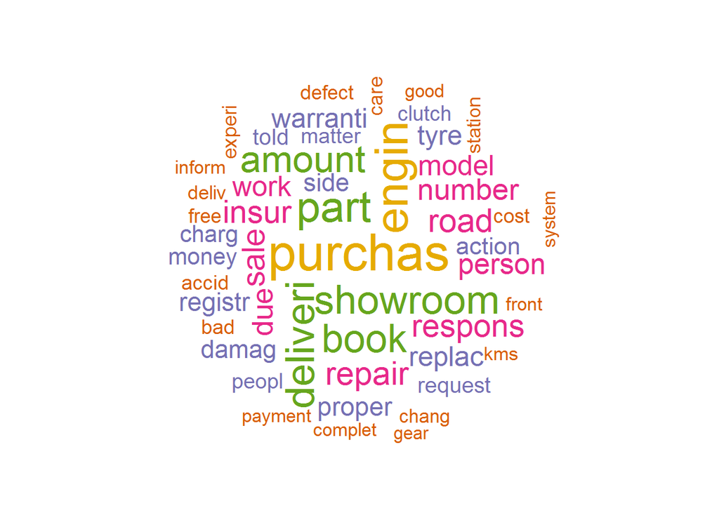

```r
content_DTM_2 <- dtm.generate(comp_keywordsDF,
                              2,0.999,
                              #spl_sym = special_symbols,
                              my_stop_word_file = stop_words_file,
                              keep.id=TRUE,
                              doIDF = FALSE)

term2_tfidf <- tapply(content_DTM_2$v/slam::row_sums(content_DTM_2)[content_DTM_2$i],
                     content_DTM_2$j, mean) *
              log2(tm::nDocs(content_DTM_2)/slam::col_sums(content_DTM_2 > 0))

summary(term2_tfidf)
```

Min. 1st Qu. Median Mean 3rd Qu. Max. 0.2986 1.1403 1.6135 1.8765 2.2995 8.0842

```r
term2_tfidf_iqr <- summary(term2_tfidf)[5] - summary(term2_tfidf)[2]
content_DTM_2.reduced <- content_DTM_2[,
                        term2_tfidf >= (summary(term2_tfidf)[2] - 1.5 * term2_tfidf_iqr)]
# term2_tfidf <= (summary(term2_tfidf)[5] + 1.5 * term2_tfidf_iqr)]

# content_DTM_2.reduced <- content_DTM_2[,
#                       term2_tfidf >= (summary(term2_tfidf)[2])]
summary(slam::col_sums(content_DTM_2.reduced))
```

Min. 1st Qu. Median Mean 3rd Qu. Max. 3.000 3.000 4.000 5.518 6.000 66.000

```r
#content_DTM_2.reduced$v <- content_DTM_2.reduced$v * (2^2)
```

### 4.3.2 Word cloud for two consecutive words

```r
wf_content_DTM_2 <- wf.generate(dtm=content_DTM_2.reduced,
                                 wc_freq = 50,
                                 wc_freq_scale = c(2, .2))
```

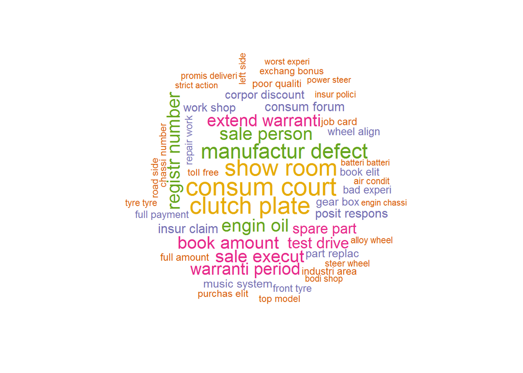

```r
content_DTM_3 <- dtm.generate(comp_keywordsDF,
                              3,0.999,
                              #spl_sym = special_symbols,
                              my_stop_word_file = stop_words_file,
                              keep.id=TRUE,
                              doIDF = FALSE)

term3_tfidf <- tapply(content_DTM_3$v/slam::row_sums(content_DTM_3)[content_DTM_3$i],
                     content_DTM_3$j, mean) *
              log2(tm::nDocs(content_DTM_3)/slam::col_sums(content_DTM_3 > 0))

summary(term3_tfidf)
```

Min. 1st Qu. Median Mean 3rd Qu. Max. 2.533 6.083 7.738 7.367 9.286 9.701

```r
term3_tfidf_iqr <- summary(term3_tfidf)[5] - summary(term3_tfidf)[2]

content_DTM_3.reduced <- content_DTM_3[,
                   term3_tfidf >= (summary(term3_tfidf)[2] - 1.5 * term3_tfidf_iqr)]
#       term3_tfidf <= (summary(term3_tfidf)[5] + 1.5 * term3_tfidf_iqr)]

# content_DTM_3.reduced <- content_DTM_3[,
#                         term3_tfidf >= (summary(term3_tfidf))[2]]

summary(slam::col_sums(content_DTM_3.reduced))
```

Min. 1st Qu. Median Mean 3rd Qu. Max. 3.000 3.000 3.000 3.725 4.000 14.000

```r
#content_DTM_3.reduced$v <- content_DTM_3.reduced$v * (3^3)
```

### 4.3.3 Word cloud for three consecutive words

```r
wf_content_DTM_3 <- wf.generate(dtm=content_DTM_3.reduced,
                                wc_freq = 50,
                                wc_freq_scale = c(2, .2))
```

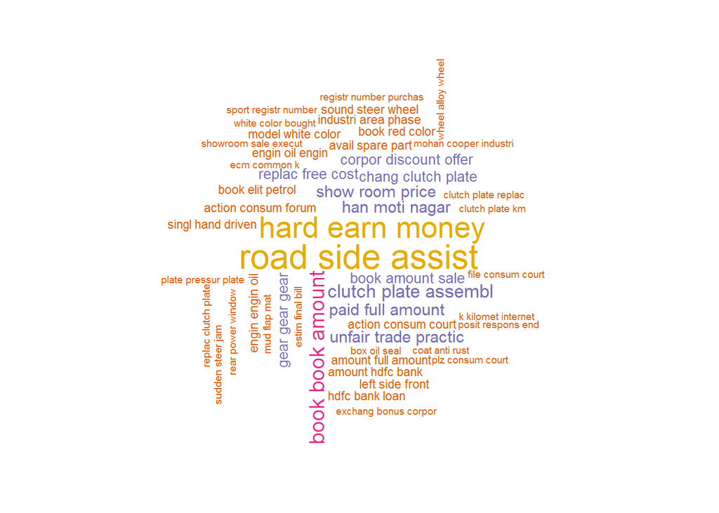

```r
content_DTM <- cbind(content_DTM_3.reduced,content_DTM_2.reduced)

content_DTM.uncl <- remove.unclustered.dtm(content_DTM)
```

### 4.3.4 Word cloud for words that will be used for topic modelling

```r
wf_content_DTM.uncl <- wf.generate(dtm=content_DTM.uncl,
                                 wc_freq = 50,
                                 wc_freq_scale = c(2, .2))
```

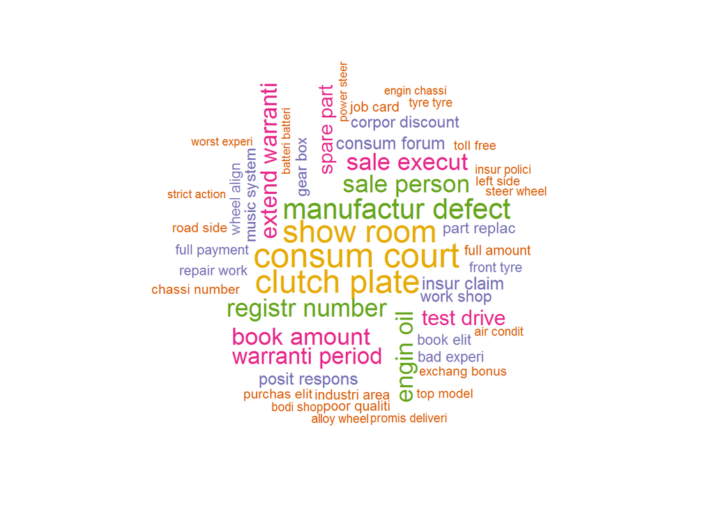

# 5 Topic Modeling

```r
content.lda.list <- generate.lda(content_DTM.uncl)
```

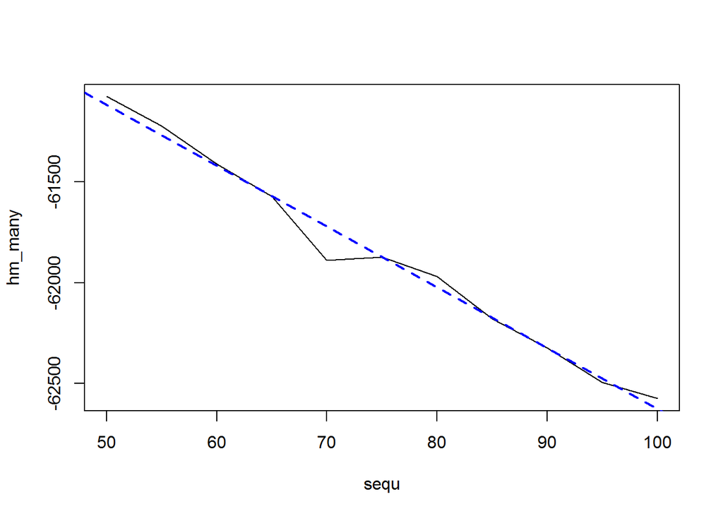

[1] " 2017-09-15 12:33:09 : Iteration 1 - coefficient: -1.00795055927353 - # topics: 50 " [1] " next iteration topic_num_interval: 5 , topic_start_num: 5 , topic_end_num: 55 "

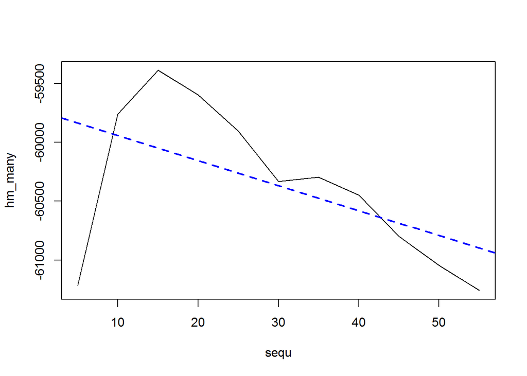

[1] " 2017-09-15 12:38:05 : Iteration 2 - coefficient: -0.567859073197787 - # topics: 15 " [1] " next iteration topic_num_interval: 5 , topic_start_num: 2 , topic_end_num: 20 "

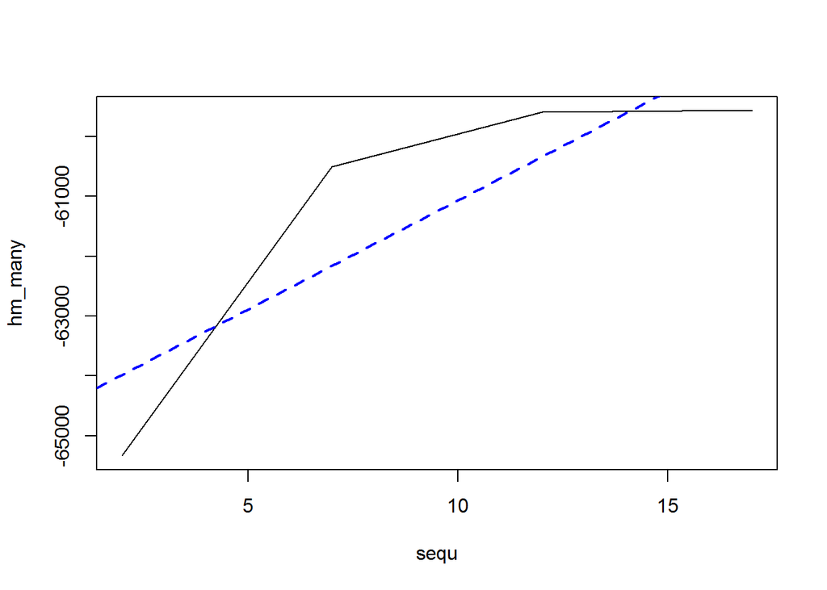

[1] " 2017-09-15 12:38:44 : Iteration 3 - coefficient: 0.947194546583236 - # topics: 17 " [1] " next iteration topic_num_interval: 2 , topic_start_num: 13 , topic_end_num: 21 "

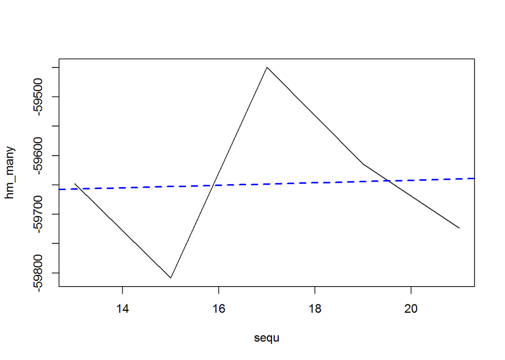

[1] " 2017-09-15 12:40:02 : Iteration 4 - coefficient: 0.047871902489322 - # topics: 17 " [1] " next iteration topic_num_interval: 1 , topic_start_num: 15 , topic_end_num: 19 "

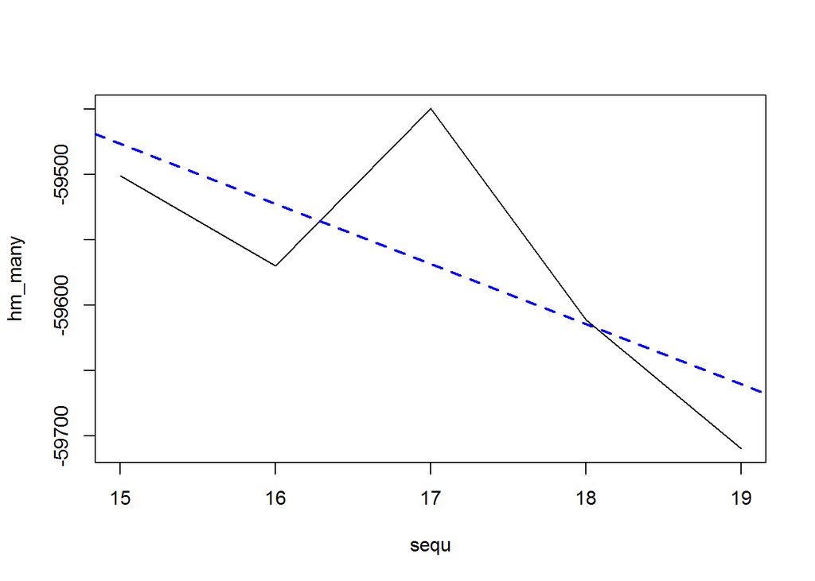

[1] " 2017-09-15 12:41:22 : Iteration 5 - coefficient: -0.705692092223823 - # topics: 17 "

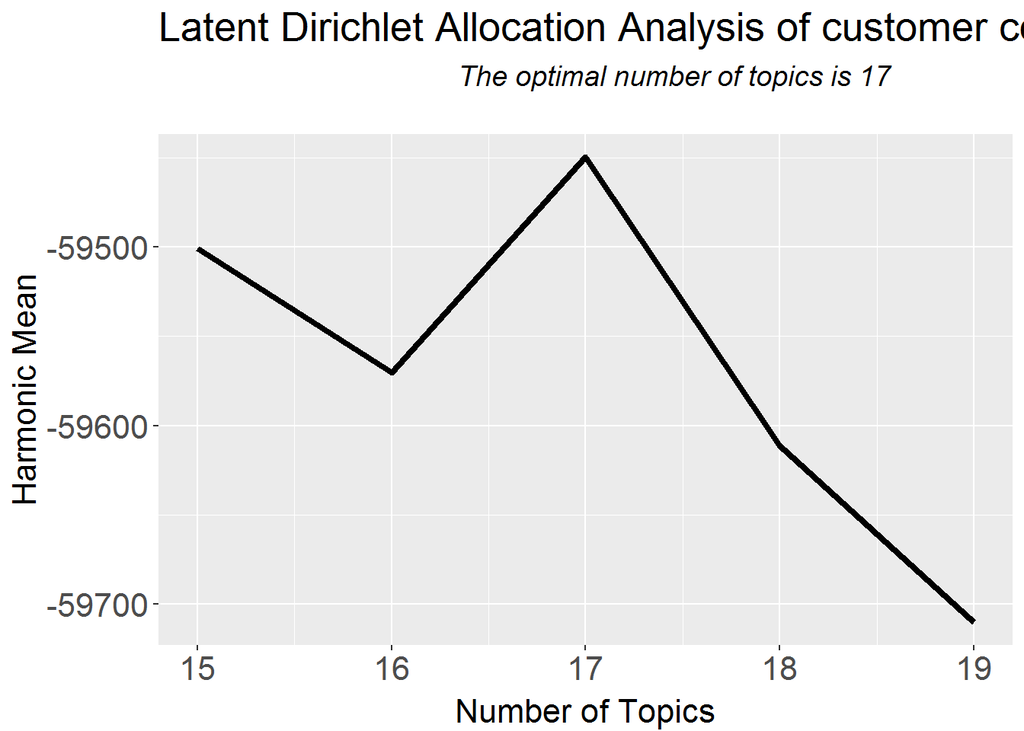

```r
content.lda.model <- content.lda.list$lda_model

content.lda.list$lda_plot
```

## 5.1 Terms for 5 topics as an example

```r
complain.topics <- topicmodels::topics(content.lda.model, 1)
## In this case I am returning the top 30 terms.
complain.topics.terms <- as.data.frame(topicmodels::terms(content.lda.model, 30),
                                       stringsAsFactors = FALSE)
print(xtable(complain.topics.terms[,1:5]),
      type="html",include.rownames = FALSE)
```

| Topic 1 | Topic 2 | Topic 3 | Topic 4 | Topic 5 |
| --- | --- | --- | --- | --- |
| registr number | chassi number | manufactur defect | engin oil | clutch plate |
| batteri batteri | job card | front tyre | consum court | cover warranti |
| toll free | free cost | music system | book elit | poor pickup |
| bodi cover | white color | alloy wheel | side assist | industri area |
| rd free | show room | work shop | road side assist | plate assembl |
| bill amount | engin number | poor qualiti | loan amount | repeat request |
| request matter | amount showroom | spare part | road side | chang clutch |
| crest jammu | extra cost | revers gear | rear bumper | labour charg |
| differ amount | huge amount | mukesh guwahati | strict action | gear stuck |
| exchang bonus | number engin | spark plug | air condition | part damag |
| himach pradesh | rc book | loan amount | front bumper | side front |
| road side | run kms | purchas elit | rear tyre | bad experi |
| accident repair | worst experi | engin part | renew insur | chasi number |
| activ sx | amount deliveri | privat limit | tyre tyre | spare wheel |
| bad qualiti | chequ chequ | showroom showroom | batteri discharg | strict action |
| left side | driven kms | brake pad | industri area | test drive |
| ac cool | mud flap | central system | insur amount | chang clutch plate |
| coolant leakag | polic station | damag replac | oil filter | clutch plate assembl |
| driver driver | respons side | engin head | road branch | cashless insur |
| exid batteri | advanc amount | engin nois | vin mala | cost readi |
| fog light | book refund | gear hard | gear gear gear | dsc nandanam |
| free accessori | commit deliveri | head light | bodi shop | fuel pump |
| long drive | deliveri promis | purchas purchas | consum forum | till receiv |
| senior person | deliveri showroom | ur peopl | fake promis | warranti period |
| wash clean | engin warranti | amount full amount | harsh indor | chequ chequ |
| work shop | extra charg | clutch plate km | major engin | injector clean |
| industri area phase | fault part | cooper industri estat | mithila showroom | proper repli |
| cash discount | high appreci | plz consum court | promis deliveri | proud owner |
| extend warranti | km km | big brand | temporari registr | recent purchas |
| matter notic | made book | caus due | amount quotat | replac free |

```r
# Creates a dataframe to store the complaint Number and the most likely topic
doctopics.df <- as.data.frame(complain.topics)
doctopics.df <- dplyr::mutate(doctopics.df,
                              complain_id = rownames(doctopics.df))
colnames(doctopics.df)[1] <- "topic_id"
doctopics.df$complain_id <- as.integer(doctopics.df$complain_id)

## Adds topic number to original dataframe of lessons
comp_topicDF <- dplyr::inner_join(compDF, doctopics.df,
                             by = c("S.No."="complain_id"))
```

## 5.2 All topics with 5 top terms

```r
topicTerms <- tidyr::gather(complain.topics.terms, Topic)
topicTerms <- cbind(topicTerms, Rank = rep(1:30))
topTerms <- dplyr::filter(topicTerms, Rank < 6)
topTerms <- dplyr::mutate(topTerms, Topic = stringr::word(Topic, 2))
topTerms$Topic <- as.numeric(topTerms$Topic)
topicLabel <- data.frame()
for (i in 1:length(complain.topics.terms)){
     z <- dplyr::filter(topTerms, Topic == i)
     l <- as.data.frame(glue::collapse(z[,2], sep = "|" ),
                        stringsAsFactors = FALSE)
     topicLabel <- rbind(topicLabel, l)

}

topicLabel <- cbind(topicLabel,rownames(topicLabel))
colnames(topicLabel) <- c("Label","topic_id")
topicLabel$topic_id <- as.numeric(as.character(topicLabel$topic_id))

comp_topicDF <- dplyr::inner_join(comp_topicDF,topicLabel,by="topic_id")

print(xtable(topicLabel),
      type="html",include.rownames = FALSE)
```

| Label | topic_id |
| --- | --- |
| registr number\|batteri batteri\|toll free\|bodi cover\|rd free | 1.00 |
| chassi number\|job card\|free cost\|white color\|show room | 2.00 |
| manufactur defect\|front tyre\|music system\|alloy wheel\|work shop | 3.00 |
| engin oil\|consum court\|book elit\|side assist\|road side assist | 4.00 |
| clutch plate\|cover warranti\|poor pickup\|industri area\|plate assembl | 5.00 |
| show room\|warranti period\|engin engin\|teflon coat\|run kms | 6.00 |
| registr number\|showroom price\|deliveri deliveri\|test drive\|driven km | 7.00 |
| insur claim\|part part\|sale execut\|damag part\|run km | 8.00 |
| gear box\|power steer\|top model\|exchang bonus\|proper respons | 9.00 |
| book amount\|sale person\|consum forum\|promis deliveri\|book book amount | 10.00 |
| consum court\|corpor discount\|full amount\|registr certif\|sale repres | 11.00 |
| sale execut\|bad experi\|fog lamp\|poor qualiti\|posit respons | 12.00 |
| extend warranti\|front side\|registr insur\|consum forum\|legal action | 13.00 |
| good condit\|test drive\|music system\|repair work\|air condit | 14.00 |
| spare part\|full payment\|book book\|repair work\|bodi shop | 15.00 |
| posit respons\|request action\|part replac\|entir amount\|number plate | 16.00 |
| wheel align\|left side\|purchas elit\|registr number\|hdfc bank | 17.00 |

# 6 Topic Visualization

## 6.1 Topic Distances and term relevance

```r
comp_keywordsDF.reduced <- comp_keywordsDF[comp_keywordsDF$ID %in%
                                             doctopics.df$complain_id,]

m <- list(id = "ID", content = colnames(comp_keywordsDF.reduced)[2])
myReader <- readTabular(mapping = m)
complain.corpus <- VCorpus(DataframeSource(comp_keywordsDF.reduced),
                           readerControl = list(reader = myReader))

complain.json <- topicmodels_json_ldavis(content.lda.model,
                                         complain.corpus, content_DTM.uncl)
serVis(complain.json,
       out.dir = 'vis',
       open.browser=FALSE)
```

[interactive chart not shown]

## 6.2 Topic correlation

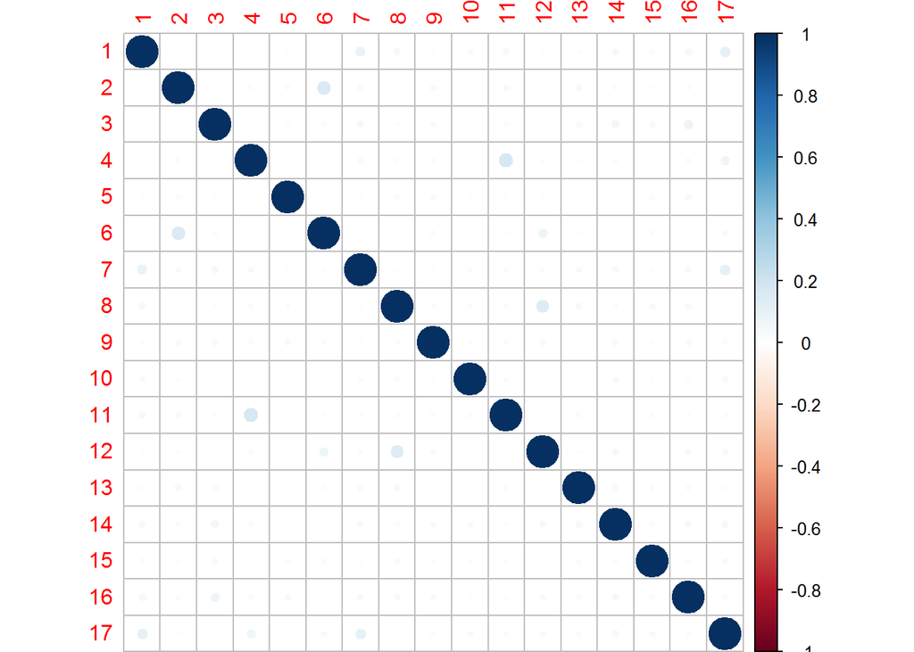

```r
word.topics <- as.data.frame(t(topicmodels::posterior(content.lda.model)$term))
word <- rownames(word.topics)
word.topics <- cbind.data.frame(word,word.topics,
                                stringsAsFactors = F)

num.col <- ncol(word.topics)
corrplot(cor(word.topics[,2:num.col]), method = "circle")
```

```r
topic_name <- c()
# create topic names using first five words
for (i in 2:num.col){
  top.words <- word.topics[order(-word.topics[,i]),1]
  topic_name <- c(topic_name,
                  paste(top.words[1:5], collapse = "|"))
}

# rename topics
colnames(word.topics) <- c("word",topic_name)
```

## 6.3 Topic Clustering

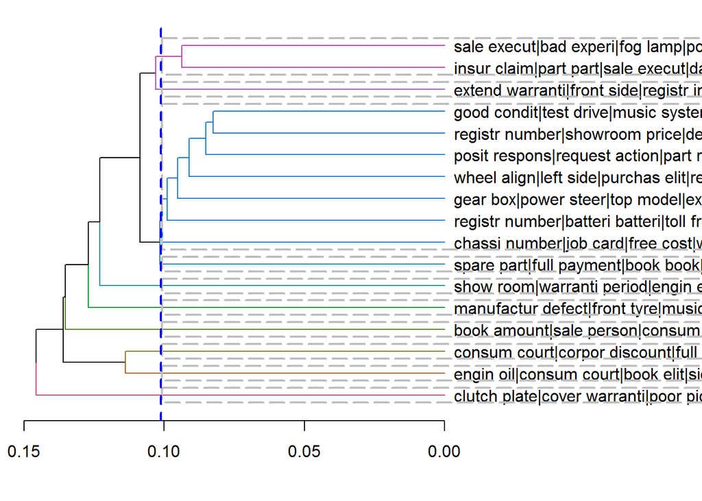

```r
m  <- as.matrix(t(word.topics))
# # # m <- m[1:2, 1:3]
distMatrix <- dist(m[2:nrow(m),], method="euclidean")
#print(distMatrix)
#distMatrix <- dist(m, method="cosine")
#print(distMatrix)

groups <- hclust(distMatrix,method="ward.D")

par(mar = c(4,1,1,12))
dend <- as.dendrogram(groups)


#library(dendextend)
# Horizontal plot
dend %>% set("branches_k_color", k = 10) %>% plot(horiz = TRUE)
dend %>% rect.dendrogram(k = 10, horiz = TRUE, border = 8, lty = 5, lwd = 2)

abline(v = heights_per_k.dendrogram(dend)["10"], lwd = 2, lty = 2, col = "blue")
```

## 6.4 Community detection

### 6.4.1 Static networks

```r
cor_threshold <- .2

cor_mat <- cor(word.topics[,2:num.col])
cor_mat[ cor_mat < cor_threshold ] <- 0
diag(cor_mat) <- 0
```

```r
graph <- graph.adjacency(cor_mat, weighted=TRUE, mode="lower")

# E(graph)$edge.width <- E(graph)$weight
# V(graph)$label <- paste(1:(ncol(word.topics)-1))
#
#
# par(mar=c(0, 0, 3, 0))
# set.seed(110)
# plot.igraph(graph, edge.width = E(graph)$edge.width,
#             edge.color = "blue", vertex.color = "white", vertex.size = 1,
#             vertex.frame.color = NA, vertex.label.color = "grey30")
# title("Strength Between Topics Based On Word Probabilities", cex.main=.8)
```

```r
clp <- cluster_label_prop(graph)
class(clp)
```

[1] “communities”

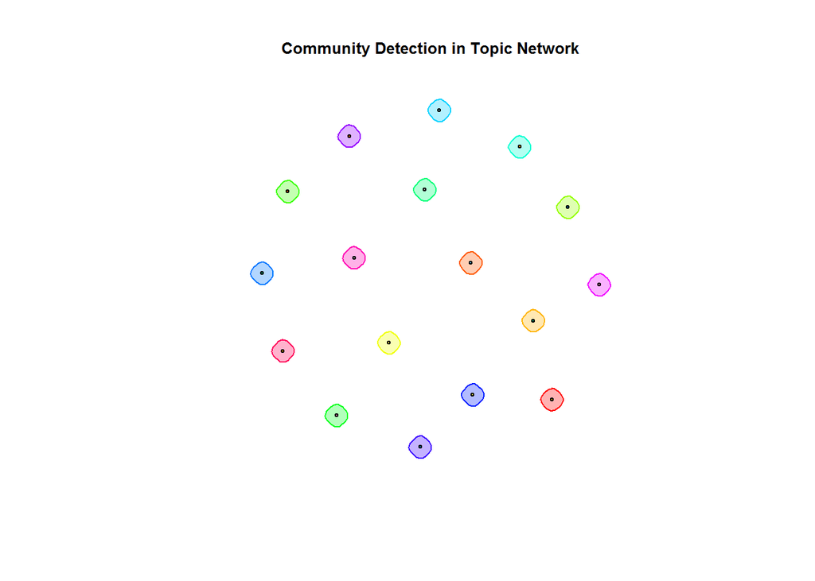

```r
plot(clp, graph, edge.width = E(graph)$edge.width, vertex.size = 2, vertex.label = "")
title("Community Detection in Topic Network", cex.main=.8)
```

```r
V(graph)$community <- clp$membership
V(graph)$betweenness <- betweenness(graph, v = V(graph), directed = F)
V(graph)$degree <- degree(graph, v = V(graph))
```

No particular clusters found

### 6.4.2 Dynamic visualization

```r
visIgraph(graph)
```

[interactive chart not shown]

# 7 Sentiment Analysis

```r
sentiment_syuzhet <- get_sentiment(comp_topicDF$Complaint.Text)
sentiment_afinn <- get_sentiment(comp_topicDF$Complaint.Text,method="afinn")
sentiment_bing <- get_sentiment(comp_topicDF$Complaint.Text,method="bing")
sentiment_nrc <- get_sentiment(comp_topicDF$Complaint.Text,method="nrc")

comp_topicDF <- cbind(comp_topicDF,
                      sentiment_syuzhet,
                      sentiment_afinn,
                      sentiment_bing,
                      sentiment_nrc)

comp_topicDF <- as.data.frame(comp_topicDF %>%
  rowwise() %>%
  mutate(sentiment_averaged = mean(c(sentiment_syuzhet,
                                     sentiment_afinn,
                                     sentiment_bing,
                                     sentiment_nrc), na.rm=T)))
```

## 7.1 Visualizing Syuzhet sentiments

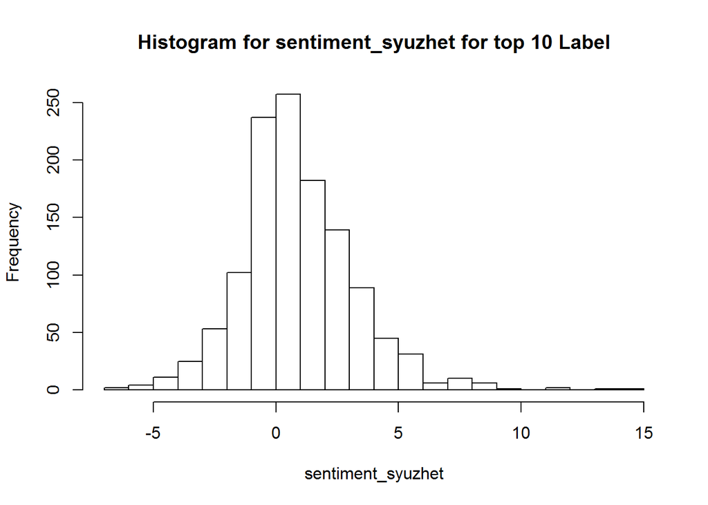

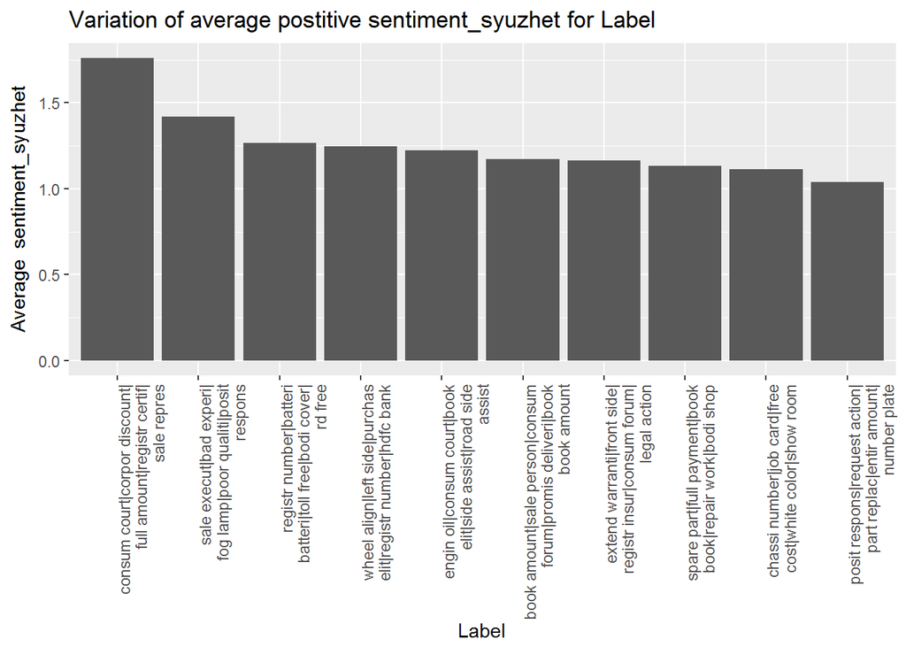

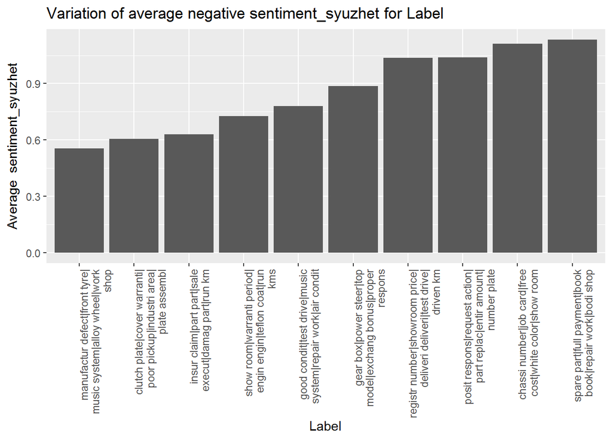

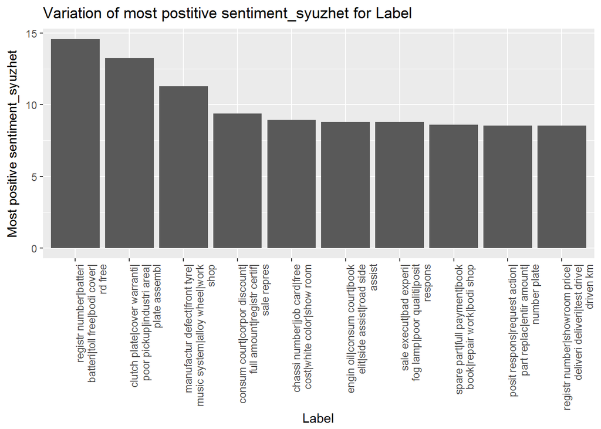

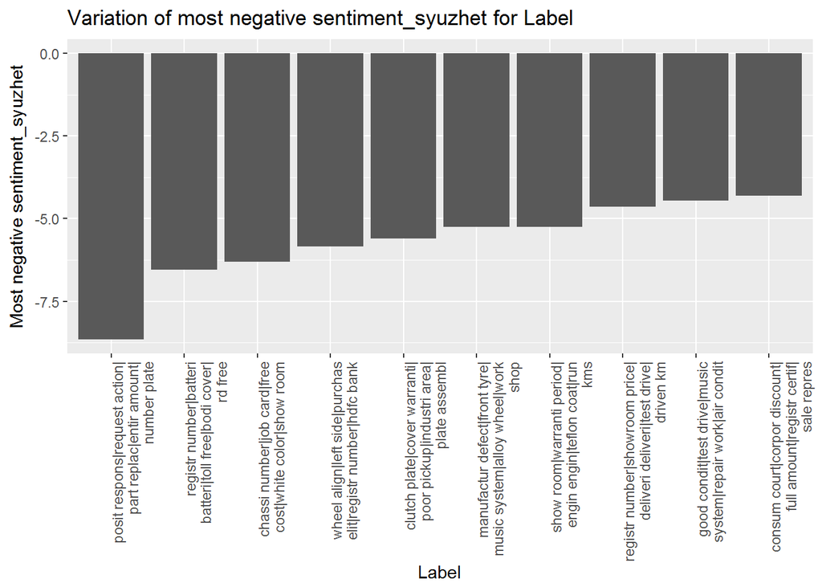

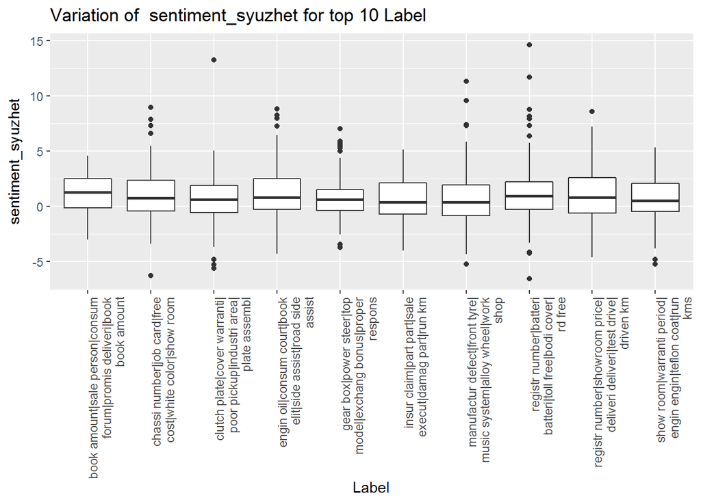

```r
create_group_plots(comp_topicDF,
                   "sentiment_syuzhet",
                   "Label",
                   10)
```

## 7.2 Visualizing Bing sentiments

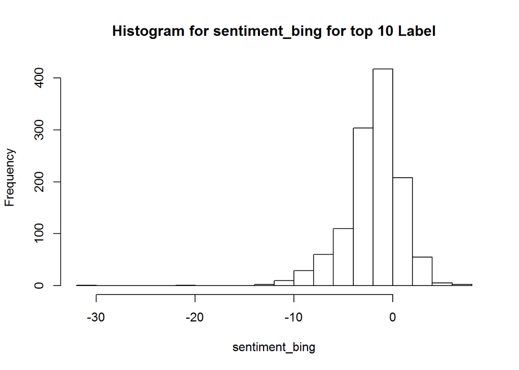

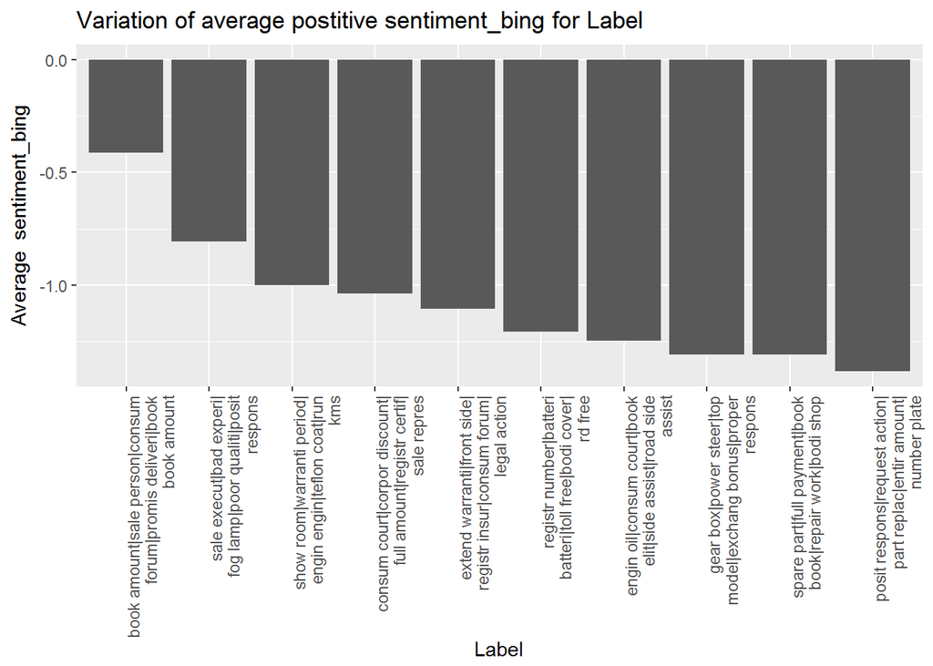

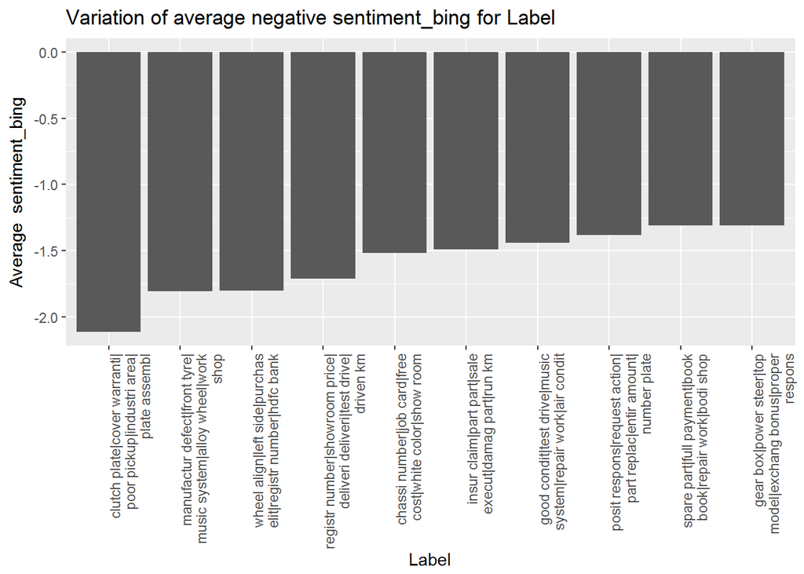

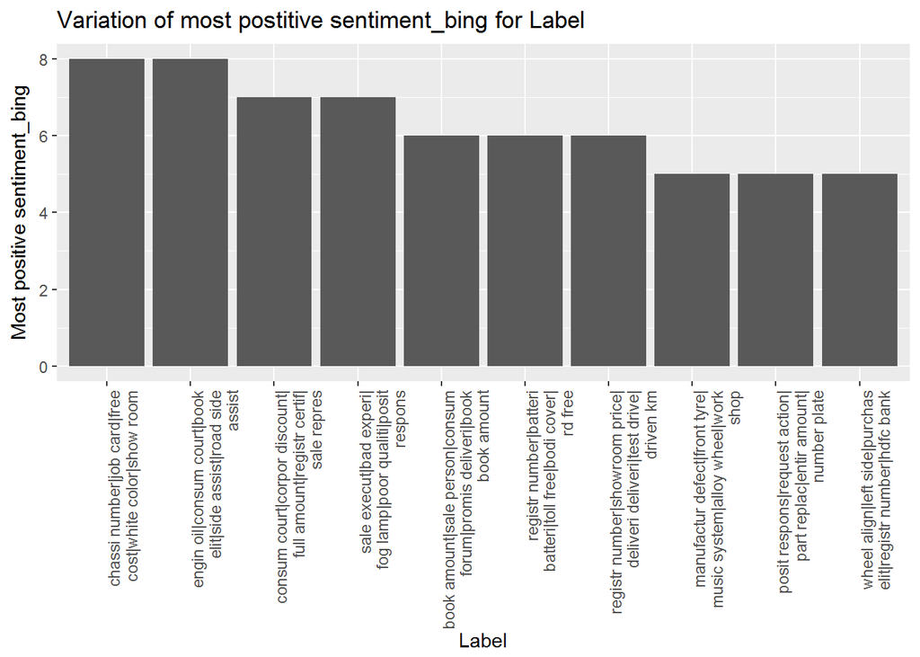

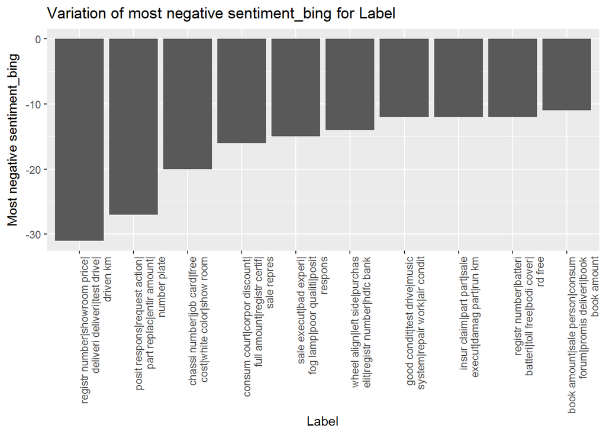

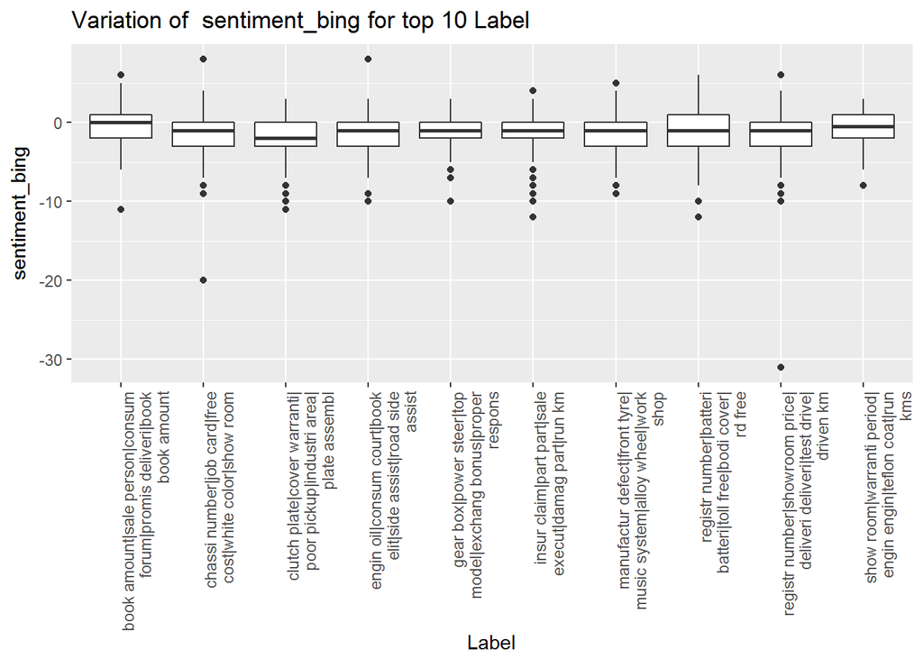

```r
create_group_plots(comp_topicDF,
                   "sentiment_bing",
                   "Label",
                   10)
```

## 7.3 Visualizing Afinn sentiments

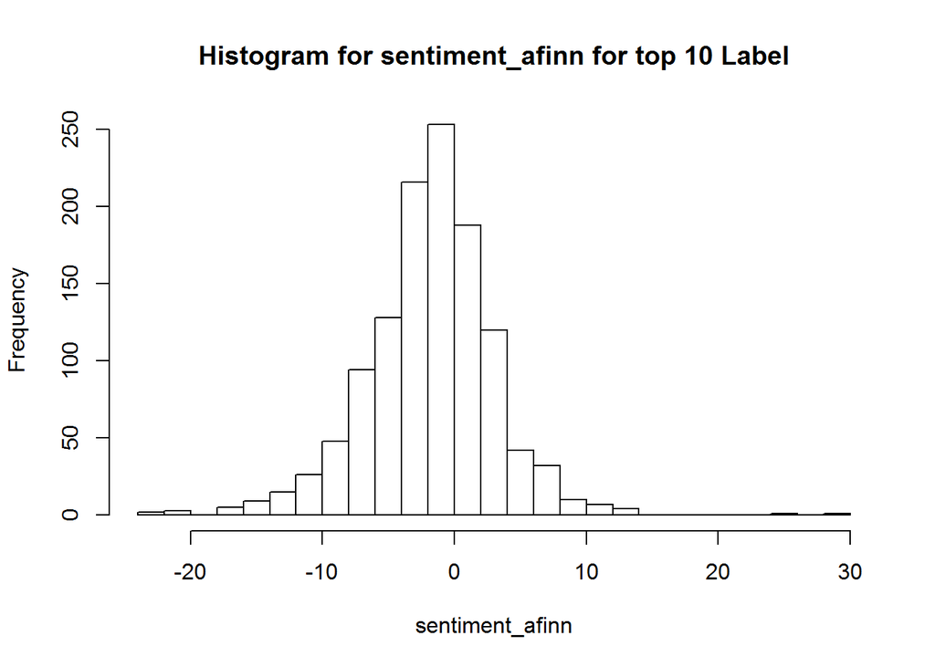

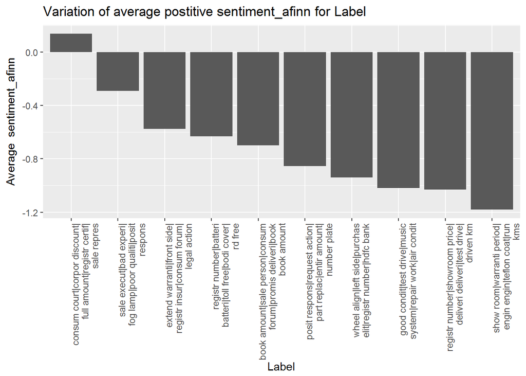

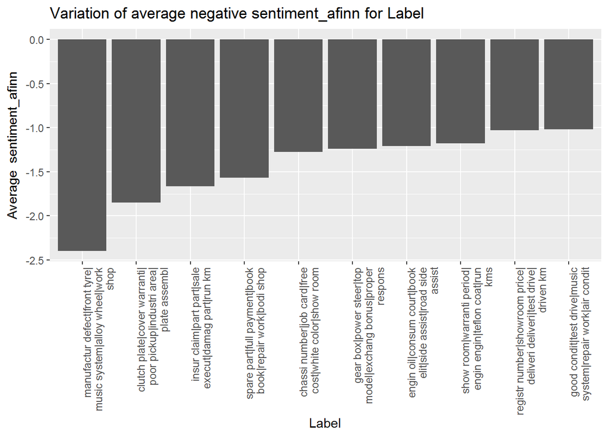

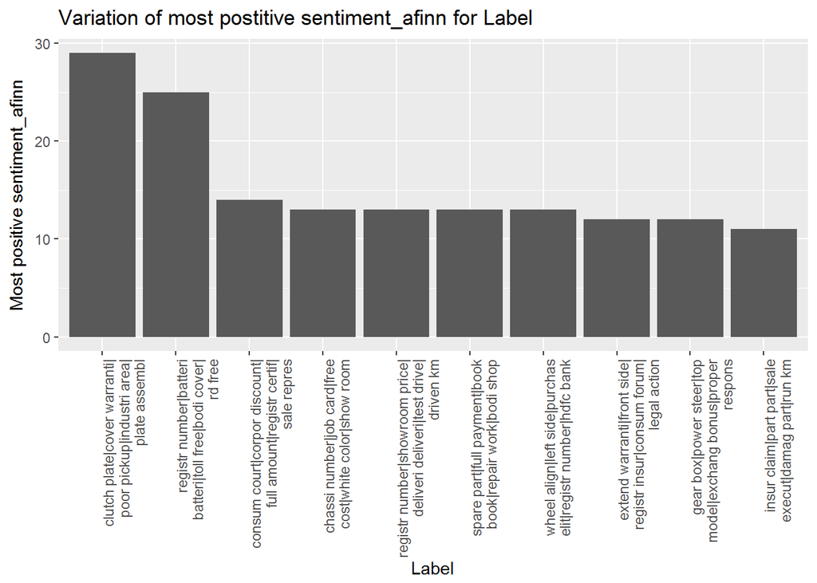

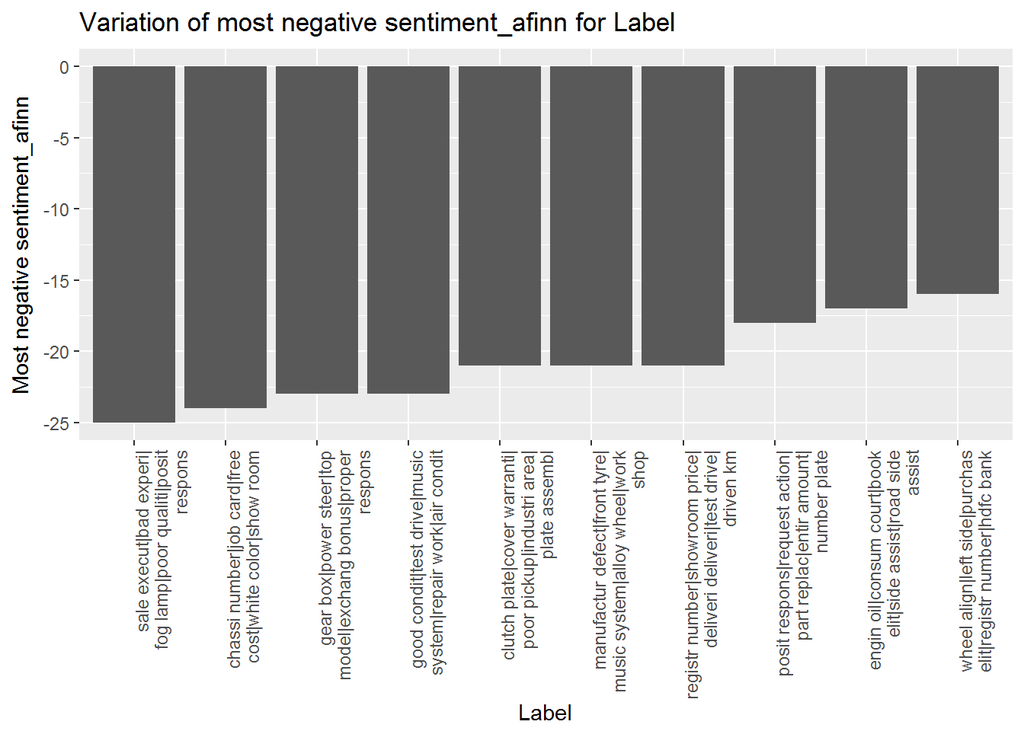

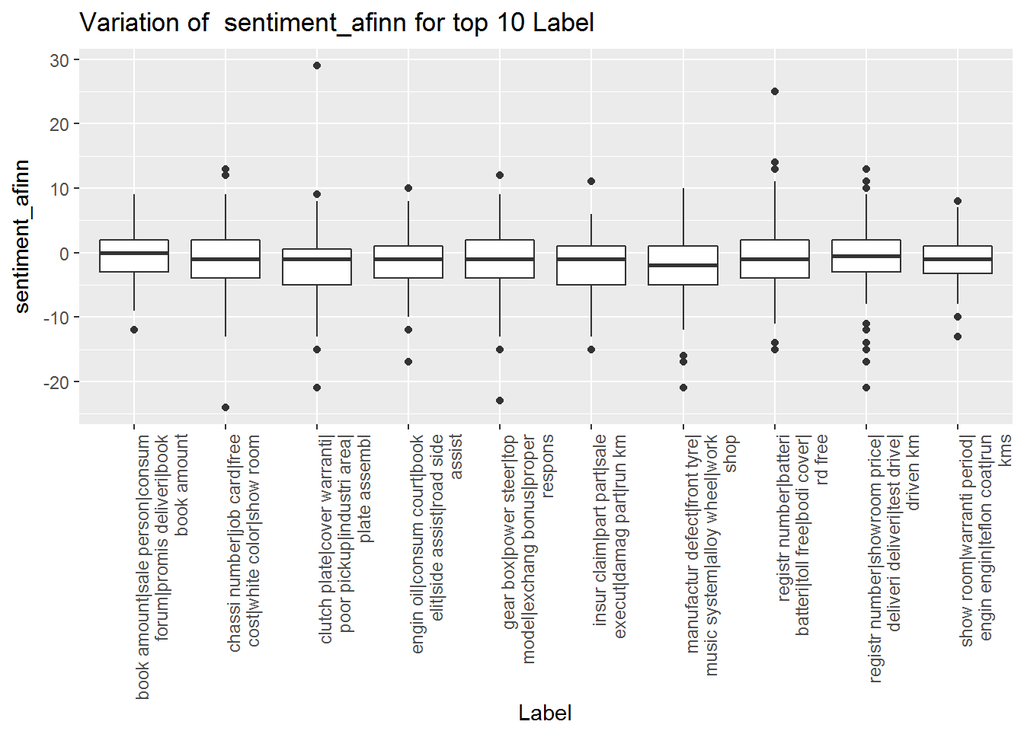

```r
create_group_plots(comp_topicDF,
                   "sentiment_afinn",
                   "Label",
                   10)
```